# PA1_template.Rmd

Jad Melki

June 14, 2015

# Loading and Processing the Data

1. Read the data frame.

```r
raw.data <- read.csv("activity.csv")
```

2. Use dplyr and plyr packages for efficient filtering and displaying.

```r
library(dplyr)
library(plyr)
data <- tbl_df(raw.data)
```

# What is the mean total number of steps taken per day?

1. Produce a cross-tabulation that calculates the total number of steps taken per day.

```r
xtabs(steps ~ date, data=data)
```

```
## date
## 2012-10-01 2012-10-02 2012-10-03 2012-10-04 2012-10-05 2012-10-06
##          0        126      11352      12116      13294      15420
## 2012-10-07 2012-10-08 2012-10-09 2012-10-10 2012-10-11 2012-10-12
##      11015          0      12811       9900      10304      17382
## 2012-10-13 2012-10-14 2012-10-15 2012-10-16 2012-10-17 2012-10-18
##      12426      15098      10139      15084      13452      10056
## 2012-10-19 2012-10-20 2012-10-21 2012-10-22 2012-10-23 2012-10-24
##      11829      10395       8821      13460       8918       8355
## 2012-10-25 2012-10-26 2012-10-27 2012-10-28 2012-10-29 2012-10-30
##       2492       6778      10119      11458       5018       9819
## 2012-10-31 2012-11-01 2012-11-02 2012-11-03 2012-11-04 2012-11-05
##      15414          0      10600      10571          0      10439
## 2012-11-06 2012-11-07 2012-11-08 2012-11-09 2012-11-10 2012-11-11
##       8334      12883       3219          0          0      12608
## 2012-11-12 2012-11-13 2012-11-14 2012-11-15 2012-11-16 2012-11-17
##      10765       7336          0         41       5441      14339
## 2012-11-18 2012-11-19 2012-11-20 2012-11-21 2012-11-22 2012-11-23
##      15110       8841       4472      12787      20427      21194
## 2012-11-24 2012-11-25 2012-11-26 2012-11-27 2012-11-28 2012-11-29
##      14478      11834      11162      13646      10183       7047
## 2012-11-30
##          0
```

2. Make a histogram of the total number of steps taken each day

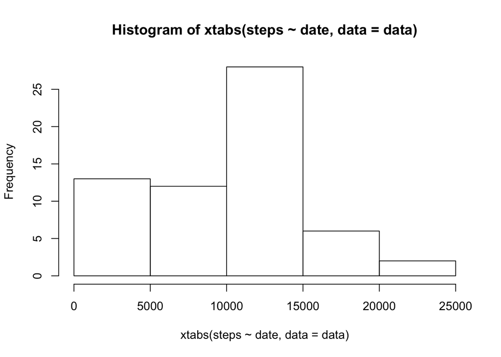

```r
hist(xtabs(steps ~ date, data=data))
```

```r
with(data, mean(steps, na.rm=TRUE))
```

```
## [1] 37.3826
```

4. Calculate median number of steps taken per day

```r
median(as.vector((xtabs(steps ~ date, data=data))))
```

```
## [1] 10395
```

# What is the average daily activity pattern?

1. Make a time series plot of the 5-minute interval (x-axis) and the average number of steps taken, averaged across all days (y-axis)

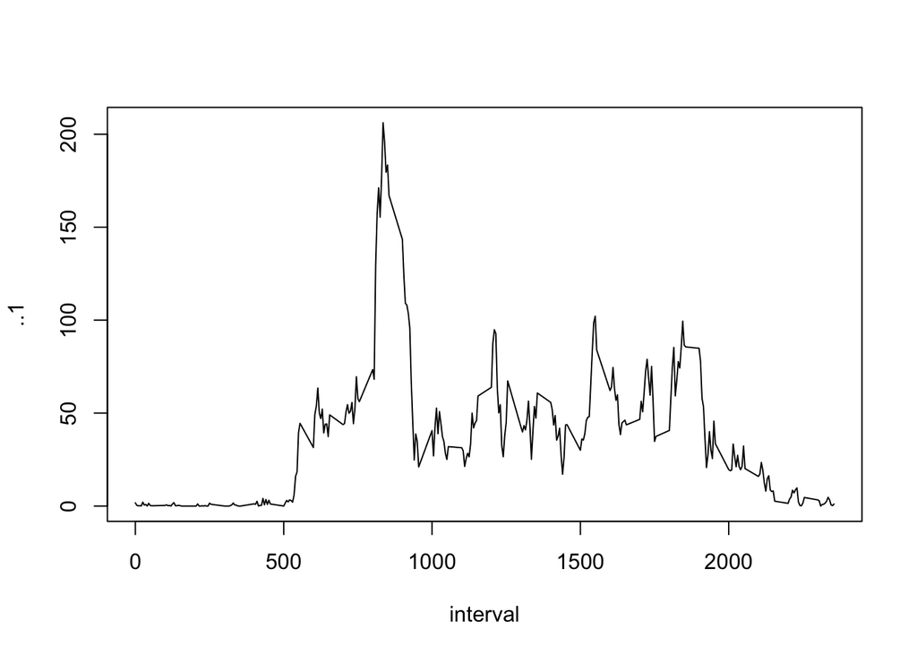

```r
data.intervals <- ddply(data, .(interval), summarise, mean(steps, na.rm=TRUE))
plot(data.intervals, type="l")
```

2. Which 5-minute interval, on average across all the days in the dataset, contains the maximum number of steps?

```r
data.intervals.max <- filter(data.intervals, data.intervals[,2]==max(data.intervals[,2]))
as.numeric(data.intervals.max$interval)
```

```
## [1] 835
```